# Probability Intro Data Analysis Project - Exploring the BRFSS data

kimnewzealand

8 June 2017

## Synopsis

This project consists of 3 parts:

1. Describe data in the BRFSS dataset.
2. Create at least three research questions to answer using these data.
3. Perform exploratory data analysis (EDA) that addresses each of the three research questions outlined above.

## Setup

### Load packages

For this analysis, the following R packages are needed `dplyr`and `ggplot2` and `reshape2`.

```r
library(ggplot2)
library(dplyr)
library(reshape2)
```

### Load data

The R working directory is set to the same folder as the current R Markdown file. The ‘brfss2013.Rdata’ file can be loaded into R using the load function, as it is a R (RData) document.

```r
setwd("~/IntroProbDataProject")
load("brfss2013.RData")
```

The dataset loaded contains a total of 491775 observations and 330 variables.

## Part 1: Data

**DATA**

The BRFSS objective is to collect uniform, state-specific data on preventive health practices and risk behaviors that are linked to chronic diseases, injuries, and preventable infectious diseases that affect the non-institutionalized adult population (18 years of age and older) residing in the US and US territories.

As per the codebook, the data for this analysis was collected over the two years 2013 and 2014 with a total of 491,773 surveys. In 2013, additional question sets to the BRFSS core survey, were included as optional modules to provide a measure for several childhood health and wellness indicators, including asthma prevalence for people aged 17 years or younger.

**SAMPLING METHOD**

The survey is conducted using Random Digit Dialing (RDD) techniques on both landlines and cell phones which is indicative of a simple random sampling method.

Since this is observational study, not experimental, it cannot be used to derive causal statements.

**POTENTIAL BIAS**

There may be non-response bias as there is a random sample that is surveyed, but the people who choose to respond may not representative of the sample.

The number of interviews within each state will however vary based on funding and the size of regions, such as health districts, within each state.There may be convenience sample bias, this occurs when individuals who are easily accessible, and are more likely to be included in the sample.

Due to the potential biases in the sample, we need to investigate whether the data in the sample is representative of and generalized to the population.

```r
# Check the first 10 variable names in the dataset compared to the codebook
head(names(brfss2013),10)
```

```
##  [1] "X_state"  "fmonth"   "idate"    "imonth"   "iday"     "iyear"
##  [7] "dispcode" "seqno"    "X_psu"    "ctelenum"
```

Based on the names of the variables in the dataset above it appears that some variable names are preceded with X.

We will use the following variables to initially investigate selected demographics in the sample:

- X_state - State Fips Code
- X_racegr3 - Computed Five Level Race/Ethnicity Category
- X_educag - Computed Level Of Education Completed Categories
- X_incomg - Computed Income Categories
- sex - Respondents Sex

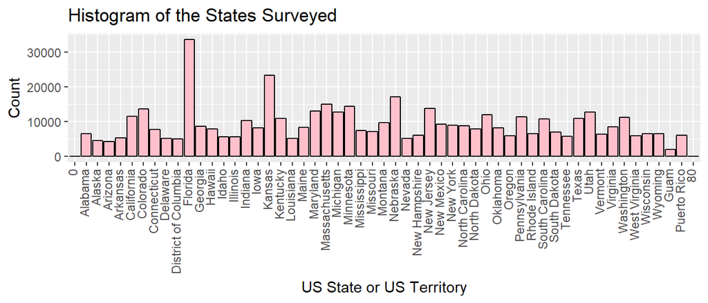

```r
# Plot a histogram of the state counts
g <- ggplot(brfss2013,aes(X_state))
g + geom_bar(colour="black",fill="pink") +
  ggtitle("Histogram of the States Surveyed") +
  theme(axis.text.x=element_text(angle=90,hjust=1,vjust=0.25)) +
  xlab("US State or US Territory") +
  ylab("Count")
```

We would expect a uniform distribution of the state counts, however there are more survey responses from Florida and Kansas, which may indicate higher survey funding in those states.

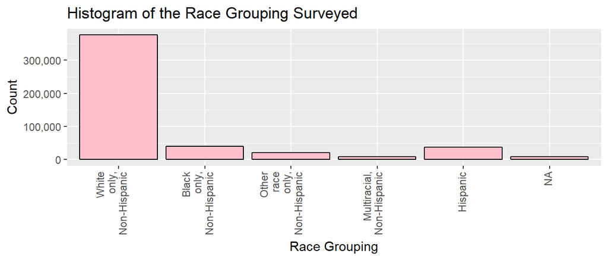

```r
# Plot a histogram of the race groupings
levels(brfss2013$X_racegr3) <- gsub(" ", "\n", levels(brfss2013$X_racegr3))
g <- ggplot(brfss2013,aes(X_racegr3))
g + geom_bar(colour="black",fill="pink") +
  ggtitle("Histogram of the Race Grouping Surveyed") +
  theme(axis.text.x=element_text(angle=90,hjust=1,vjust=0.25)) +
  xlab("Race Grouping") +
  scale_y_continuous(labels=scales::comma,"Count")
```

The race grouping indicates predominately ‘White only, Non Hispanic’ responses.

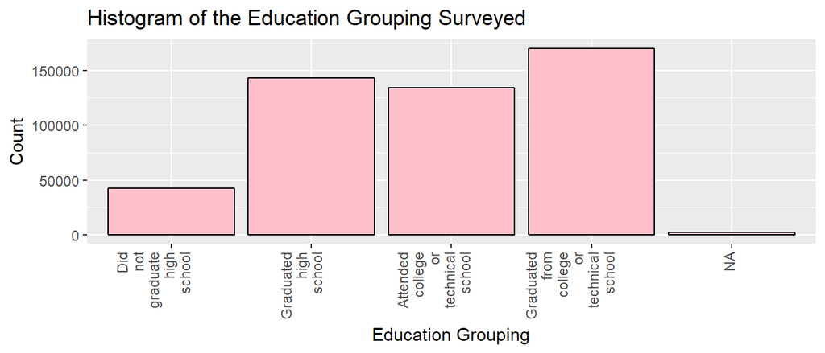

```r
# Plot a barplot of the education grouping
levels(brfss2013$X_educag) <- gsub(" ", "\n", levels(brfss2013$X_educag))
g <- ggplot(brfss2013,aes(X_educag))
g + geom_bar(colour="black",fill="pink") +
  ggtitle("Histogram of the Education Grouping Surveyed") +
  theme(axis.text.x=element_text(angle=90,hjust=1,vjust=0.25)) +
  xlab("Education Grouping") +
  ylab("Count")
```

The education grouping most surveyed is ‘Graduated from college or technical school’

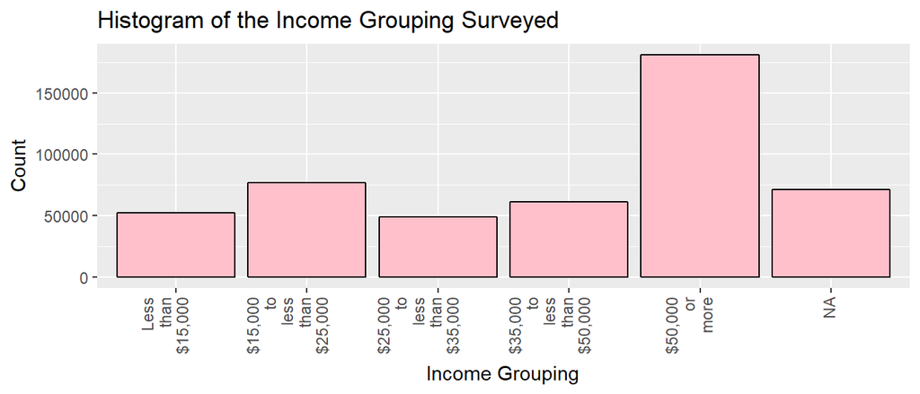

```r
# Plot a barplot of the income grouping
levels(brfss2013$X_incomg) <- gsub(" ", "\n", levels(brfss2013$X_incomg))
g <- ggplot(brfss2013,aes(X_incomg))
g + geom_bar(colour="black",fill="pink") +
  ggtitle("Histogram of the Income Grouping Surveyed") +
  theme(axis.text.x=element_text(angle=90,hjust=1,vjust=0.25)) +
  xlab("Income Grouping") +
  ylab("Count")
```

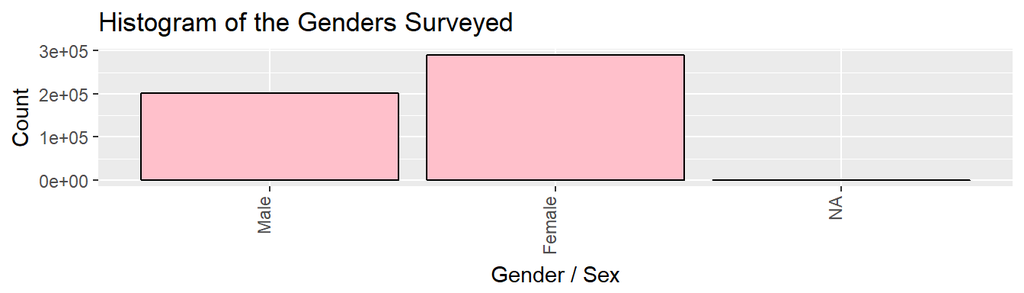

```r
# Plot a histogram of the sex counts
g <- ggplot(brfss2013,aes(sex))
g + geom_bar(colour="black",fill="pink") +
    ggtitle("Histogram of the Genders Surveyed") +
    theme(axis.text.x=element_text(angle=90,hjust=1,vjust=0)) +
    xlab("Gender / Sex") +
    ylab("Count")
```

There are more female respondents than males in this data.

### Missing data

All missing values are coded NA in the R Workspace. We assume that these represent Don’t know/Not Sure Or Refused/Missing and will not remove or replace unless otherwise stated.

## Part 2: Research questions

**Research quesion 1:** As a first question, we might be interested in exploring the relationship between the intake of of fruits and chronic diseases. Specifically does the number of fruit eaten on a daily basis impact onset of a type of chronic heart disease. This may be useful to explore potential fruit campaigns as a prevention of chronic heart disease(s) in GP surgeries to promote well-being.

**Research quesion 2:** Next we could explore the relationship between smoking and other chronic health conditions. Specifically does smoking a daily basis impact onset of arthritis. This could useful to as a basis for campaigns in GP surgeries to promote well-being.

**Research quesion 3:** Next we could explore the relationship between exercise and health. We could investigate Exercise (Physical Activity) and Healthy Days to explore if campaigns for daily exercise could be promoted to encourage health living in GP surgeries.

## Part 3: Exploratory data analysis

**Research quesion 1:**

As a first question, we might be interested in exploring the relationship between the intake of of fruits and chronic heart diseases.

The following are the computed variables that we will analyse as the explanatory variables as they are summaries of the fruit intake as Yes, No, NA responses. The actual data set variable names are preceded with the value ‘X’:

- _frtlt1: Consume Fruit 1 Or More Times Per Day
- _frt16: Reported Consuming Fruit >16/Day. Ignore this variable as 99.98 % Included - Values are in accepted range

```r
# Since this is a large dataset we can use the `dplyr` chain to select the variables of interest and investigate only their structure by adding `str()` at the end of the chain:
brfss2013 %>%
  select(X_frtlt1) %>%
  str()
```

```
## 'data.frame':    491775 obs. of  1 variable:
##  $ X_frtlt1: Factor w/ 2 levels "Consumed fruit one or more times per day",..: 1 2 2 2 2 1 1 2 1 2 ...
```

For the response variables, the Chronic Health Conditions in the Main Survey - Section 7, which are Yes, No, NA responses related to Heart conditions, are the following :

- cvdinfr4: Ever Diagnosed With Heart Attack
- cvdcrhd4: Ever Diagnosed With Angina Or Coronary Heart Disease
- cvdstrk3: Ever Diagnosed With A Stroke

```r
# Investigate the structure of the heart conditions
brfss2013 %>%
  group_by(cvdinfr4, cvdcrhd4,cvdstrk3) %>%
  summarise(count = n())
```

```
## Source: local data frame [27 x 4]
## Groups: cvdinfr4, cvdcrhd4 [?]
##
##    cvdinfr4 cvdcrhd4 cvdstrk3 count
##      <fctr>   <fctr>   <fctr> <int>
## 1       Yes      Yes      Yes  3004
## 2       Yes      Yes       No 10853
## 3       Yes      Yes       NA    96
## 4       Yes       No      Yes  2395
## 5       Yes       No       No 11415
## 6       Yes       No       NA    96
## 7       Yes       NA      Yes   314
## 8       Yes       NA       No  1075
## 9       Yes       NA       NA    36
## 10       No      Yes      Yes  1761
## # ... with 17 more rows
```

```r
# Produce summary statistics of the Consume Fruit 1 Or More Times Per Day variable
summary(brfss2013$X_frtlt1)
```

```
##  Consumed fruit one or more times per day
##                                    291729
## Consumed fruit less than one time per day
##                                    171343
##                                      NA's
##                                     28703
```

```r
# Produce summary statistics of the Ever Diagnosed With Heart Attack  variable
summary(brfss2013$cvdinfr4)
```

```
##    Yes     No   NA's
##  29284 459904   2587
```

```r
# Produce summary statistics of theEver Diagnosed With Angina Or Coronary Heart Disease  variable
summary(brfss2013$cvdcrhd4)
```

```
##    Yes     No   NA's
##  29064 458288   4423
```

```r
# Produce summary statistics of the Ever Diagnosed With A Stroke variable
summary(brfss2013$cvdstrk3)
```

```
##    Yes     No   NA's
##  20391 469917   1467
```

```r
# First we need to create a frequency or contingency table using table() and a relative frequency table using prop.table() for heart attack
brfss2013$X_frtlt1 <- as.character(brfss2013$X_frtlt1)
fruittable1 <- with(brfss2013,(table("fruit"=X_frtlt1,"heart.attack"=cvdinfr4,useNA="always")))
fruittable1
```

```
##                                            heart.attack
## fruit                                          Yes     No   <NA>
##   Consumed fruit less than one time per day  10746 159651    946
##   Consumed fruit one or more times per day   16962 273392   1375
##   <NA>                                        1576  26861    266
```

```r
fruittable1 <- round(prop.table(fruittable1),2)
fruittable1
```

```
##                                            heart.attack
## fruit                                        Yes   No <NA>
##   Consumed fruit less than one time per day 0.02 0.32 0.00
##   Consumed fruit one or more times per day  0.03 0.56 0.00
##   <NA>                                      0.00 0.05 0.00
```

```r
# Create a frequency or contingency table using table() and a relative frequency table using prop.table() for Anginas
fruittable2 <- with(brfss2013,(table("fruit"=X_frtlt1,"angina"=cvdcrhd4,useNA="always")))
fruittable2
```

```
##                                            angina
## fruit                                          Yes     No   <NA>
##   Consumed fruit less than one time per day  10398 159274   1671
##   Consumed fruit one or more times per day   17295 272029   2405
##   <NA>                                        1371  26985    347
```

```r
fruittable2 <- round(prop.table(fruittable2),2)
fruittable2
```

```
##                                            angina
## fruit                                        Yes   No <NA>
##   Consumed fruit less than one time per day 0.02 0.32 0.00
##   Consumed fruit one or more times per day  0.04 0.55 0.00
##   <NA>                                      0.00 0.05 0.00
```

```r
# Create a frequency or contingency table using table() and a relative frequency table using prop.table() for Strokes
fruittable3 <- with(brfss2013,(table("fruit"=X_frtlt1,"stroke"=cvdstrk3,useNA="always")))
fruittable3
```

```
##                                            stroke
## fruit                                          Yes     No   <NA>
##   Consumed fruit less than one time per day   7452 163343    548
##   Consumed fruit one or more times per day   11799 279153    777
##   <NA>                                        1140  27421    142
```

```r
fruittable3 <- round(prop.table(fruittable3),2)
fruittable3
```

```
##                                            stroke
## fruit                                        Yes   No <NA>
##   Consumed fruit less than one time per day 0.02 0.33 0.00
##   Consumed fruit one or more times per day  0.02 0.57 0.00
##   <NA>                                      0.00 0.06 0.00
```

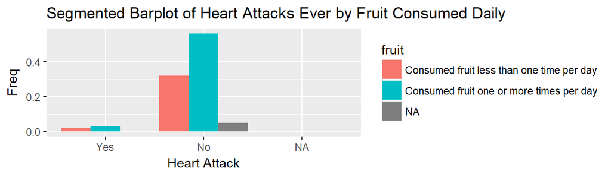

```r
# Plot the Segmented barplot to view the relative frequencies of the count of the heart attacks by fruit consumed daily
fruittable1 <- as.data.frame(fruittable1)
g <- ggplot(fruittable1, aes(heart.attack, Freq))
g + geom_bar(stat="identity",aes(fill = fruit),position = "dodge") +
      labs(title="Segmented Barplot of Heart Attacks Ever by Fruit Consumed Daily",x="Heart Attack")
```

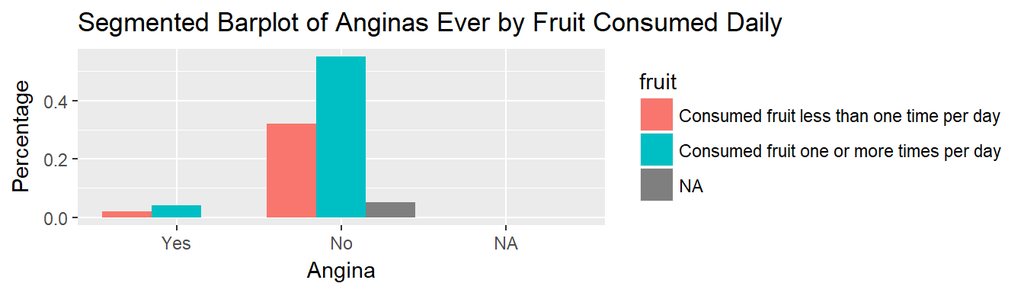

```r
# Plot the Segmented barplot to view the relative frequencies of the count of the heart attacks by fruit consumed daily
fruittable2 <- as.data.frame(fruittable2)
g <- ggplot(fruittable2, aes(angina, Freq))
g + geom_bar(stat="identity",aes(fill = fruit),position = "dodge") +
      labs(title="Segmented Barplot of Anginas Ever by Fruit Consumed Daily",x="Angina",y="Percentage")
```

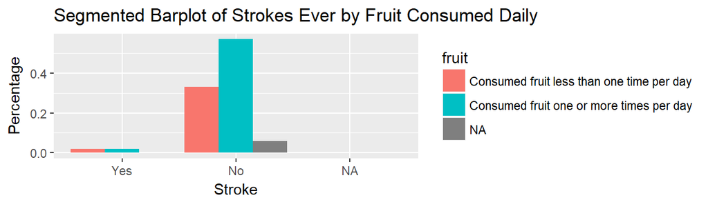

```r
# Plot the the Segmented barplot to view the relative frequencies of the count of the heart attacks by fruit consumed daily
fruittable3 <- as.data.frame(fruittable3)
g <- ggplot(fruittable3, aes(stroke, Freq))
g + geom_bar(stat="identity",aes(fill = fruit),position = "dodge") +
      labs(title="Segmented Barplot of Strokes Ever by Fruit Consumed Daily",x="Stroke",y="Percentage")
```

From the above tables and graphs, for heart attacks, anginas and strokes, the proportion of those who did not have either of these diseases that consumed fruit more than one a day is higher than for those who did have a disease.

**Research quesion 2:**

We will use the following response variable:

We will use the following computed variable, to match lifetime diagnoses, as the explanatory variable: X_smoker3: Computed Smoking Status over entire life

The response variable relates to diagnosis over lifetime therefore will not use these three smoking related explanatory variables as they are shorter timespans:

- smoke100: Smoked At Least 100 Cigarettes
- smokday2: Frequency Of Days Now Smoking
- stopsmk2: Stopped Smoking In Past 12 Months

```r
# Since this is a large dataset we can use the `dplyr` chain to select the variables of interest and investigate their structure by adding `str()` at the end of the chain:
brfss2013 %>%
  select(X_smoker3) %>%
  str()
```

```
## 'data.frame':    491775 obs. of  1 variable:
##  $ X_smoker3: Factor w/ 4 levels "Current smoker - now smokes every day",..: 3 4 2 4 3 4 3 1 4 4 ...
```

```r
# Produce summary statistics of the variable under investigation
summary(brfss2013$X_smoker3)
```

```
## Current smoker - now smokes every day
##                                 55162
## Current smoker - now smokes some days
##                                 21495
##                         Former smoker
##                                138134
##                          Never smoked
##                                261651
##                                  NA's
##                                 15333
```

The Chronic Health Conditions in the Main Survey - Section 7, which are Yes, No, NA responses related to Heart conditions are the following:

cvdinfr4: Ever Diagnosed With Heart Attack havarth3: Told Have Arthritis

```r
# First we need to create a frequency or contingency table using table() and a relative frequency table using prop.table()
brfss2013$X_frtlt1 <- as.character(brfss2013$X_smoker3)
smoketable <- with(brfss2013,(table("smoke"=X_smoker3,"arthritis"=havarth3,useNA="always")))
smoketable
```

```
##                                        arthritis
## smoke                                      Yes     No   <NA>
##   Current smoker - now smokes every day  19511  35261    390
##   Current smoker - now smokes some days   7130  14207    158
##   Former smoker                          57721  79570    843
##   Never smoked                           76415 183854   1382
##   <NA>                                    4375  10761    197
```

```r
smoketable <- round(prop.table(smoketable),2)
smoketable
```

```
##                                        arthritis
## smoke                                    Yes   No <NA>
##   Current smoker - now smokes every day 0.04 0.07 0.00
##   Current smoker - now smokes some days 0.01 0.03 0.00
##   Former smoker                         0.12 0.16 0.00
##   Never smoked                          0.16 0.37 0.00
##   <NA>                                  0.01 0.02 0.00
```

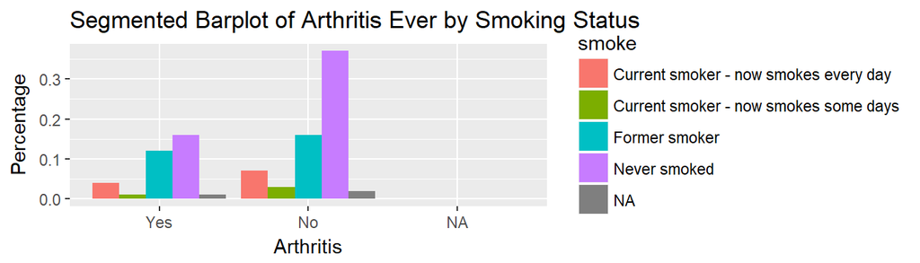

```r
# Plot the segmented barplot to view the relative frequencies of the count of ever having arthritis by smoking status
smoketable <- as.data.frame(smoketable)
g <- ggplot(smoketable, aes(arthritis, Freq))
g + geom_bar(stat="identity",aes(fill = smoke),position = "dodge") +
      labs(title="Segmented Barplot of Arthritis Ever by Smoking Status",x="Arthritis",y="Percentage")
```

A large proportion of those that have never smoked have not been diagnosed with arthritis, relative to the those that have been diagnosed.

**Research quesion 3:**

We can explore the following explanatory variables:

- exerhmm1: Minutes Or Hours Walking, Running, Jogging, Or Swimming first activity
- exerhmm2: Minutes Or Hours Walking, Running, Jogging, Or Swimming second activity

The response variable we are going to look at is :  
- genhlth: General Health

```r
# Since this is a large dataset we can use the `dplyr` chain to select the variables of interest and investigate only their structure by adding `str()` at the end of the chain:
brfss2013 %>%
  select(exerhmm1,exerhmm2,genhlth) %>%
  str()
```

```
## 'data.frame':    491775 obs. of  3 variables:
##  $ exerhmm1: int  NA 20 NA 30 NA 15 100 15 100 30 ...
##  $ exerhmm2: int  NA 10 NA NA NA 30 NA NA NA 100 ...
##  $ genhlth : Factor w/ 5 levels "Excellent","Very good",..: 4 3 3 2 3 2 4 3 1 3 ...
```

```r
# Summary statistics of Minutes Or Hours Walking, Running, Jogging, Or Swimming 1
summary(brfss2013$exerhmm1)
```

```
##    Min. 1st Qu.  Median    Mean 3rd Qu.    Max.    NA's
##    1.00   30.00   45.00   92.95  100.00  959.00  168395
```

```r
# Summary statistics of Minutes Or Hours Walking, Running, Jogging, Or Swimming 2
summary(brfss2013$exerhmm2)
```

```
##    Min. 1st Qu.  Median    Mean 3rd Qu.    Max.    NA's
##     0.0    30.0    45.0   109.2   130.0   959.0  283651
```

```r
# Combine the 2 sets of minutes into a total new column called exerhmm for Combined Exercise time
brfss2013 <- brfss2013 %>%
  mutate(exerhmm = exerhmm1+exerhmm2)

# Summary statistics of Combined Minutes Or Hours Walking, Running, Jogging, Or Swimming 2
summary(brfss2013$exerhmm)
```

```
##    Min. 1st Qu.  Median    Mean 3rd Qu.    Max.    NA's
##     2.0    70.0   145.0   207.4   260.0  1918.0  285812
```

```r
# View General Health as a proportion table
summary(brfss2013$genhlth)
```

```
## Excellent Very good      Good      Fair      Poor      NA's
##     85482    159076    150555     66726     27951      1985
```

```r
gentable <- table(brfss2013$genhlth)
gentable <- as.data.frame(prop.table(gentable))
names(gentable)<-c("general.health","percentage")
gentable
```

```
##   general.health percentage
## 1      Excellent 0.17452786
## 2      Very good 0.32478409
## 3           Good 0.30738684
## 4           Fair 0.13623390
## 5           Poor 0.05706731
```

From these summary statistics we can see the total number of NA’s. These are the number who do not know or refused to answer. We will therefore not remove or change these values.

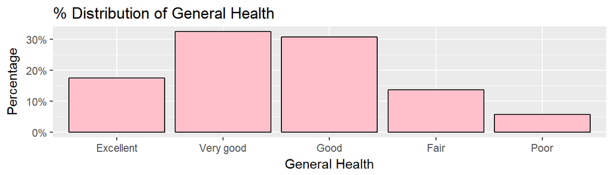

```r
# Plot a barplot to see the % distribution of General Health
gentable <- as.data.frame(gentable)
g <- ggplot(gentable,aes(general.health,percentage))
g + geom_bar(stat="identity",colour="black",fill="pink") +
    labs(title= "% Distribution of General Health",x="General Health",y="Percentage") +
    scale_y_continuous(labels=scales::percent)
```

The distribution of General Health is slightly right skewed.

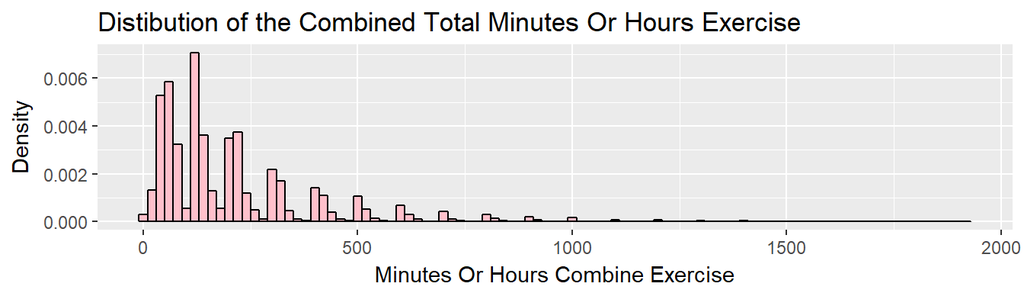

```r
# Plot a histogram to see the distibution of the combined total Minutes Or Hours Walking, Running, Jogging, Or Swimming
g <- ggplot(brfss2013,aes(exerhmm))
g + geom_histogram(binwidth=20, aes(y=..density..),color="black",fill="pink") +
  stat_function(fun=dnorm,args=list(mean=mean(brfss2013$exerhmm),sd=sd(brfss2013$exerhmm)),geom="line",color = "black", size = 1.0) +
  scale_x_continuous("Minutes Or Hours Combine Exercise") +
  labs(title="Distibution of the Combined Total Minutes Or Hours Exercise",y="Density")
```

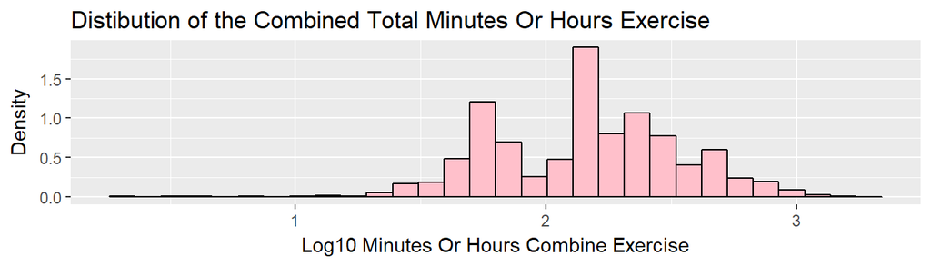

```r
# Plot a the histogram from above with a log f the exerhmm variable
g <- ggplot(brfss2013,aes(log10(exerhmm)))
g + geom_histogram(aes(y=..density..),color="black",fill="pink") +
    stat_function(fun=dnorm, args=list(mean=mean(brfss2013$exerhmm), sd=sd(brfss2013$exerhmm)), geom="line", color = "black", size = 1.0) +
  scale_x_continuous("Log10 Minutes Or Hours Combine Exercise") +
  scale_y_continuous("Density")+
  labs(title="Distibution of the Combined Total Minutes Or Hours Exercise")
```

The log distribution of combined total Minutes Or Hours Walking, Running, Jogging, Or Swimming has bi-modal distribution.

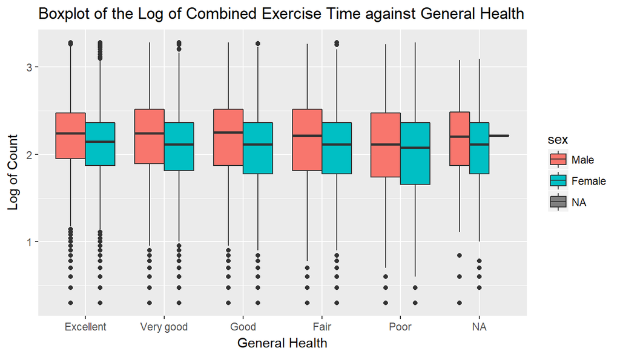

```r
# Plot a boxplot to view the relationship between the log of thetotal Minutes Or Hours Walking, Running, Jogging, Or Swimming and General Health, Number Of Days Physical Health Not Good and Poor Physical Or Mental Health over the last 30 days.
# Add 3rd variable sex as a blocker.

g <- ggplot(brfss2013,aes(genhlth,log10(exerhmm)))
g + geom_boxplot(aes(fill=sex)) +
     labs(title= "Boxplot of the Log of Combined Exercise Time against General Health", x="General Health", y="Log of Count")
```

The median and IQR is similar across the general health categories, except for the poor category. It is also lower for females than males across all the categories. For males it appears that there may be a relationship between exercise time and poor health.

**Conclusion**

We investigated three questions using the BRFSS dataset. The BRFSS is an observational study of non-institutionalized adult population (18 years of age and older) residing in the US and US territories using a random sampling method.

The sample may be generalized to population if the race/ethnicity grouping is representative of the population. However it appears that there is potentially non-response bias due to the larger number of responses from females, higher educated and higher income respondents.